# VT Parity

Initial packages

```r
rm(list=ls(all=TRUE))
library(ape)
library(treeplyr)
library(rotl)
library(castor)
library(geiger)
library(phytools)
library(phylolm)
dat <- read.csv("../datasets/vtparity.csv")
```

I. Tree Generation - Can Skip to II and just load synthesis td.

```r
amphib <- drop.tip(read.tree("./amph_shl_new_Consensus_7238.tre"), "Homo_sapiens") #Jetz & Pyron 2018
birds <- read.tree("~/repos/bmr/datasets/bird.tre") #Jetz
squam <- read.tree("~/repos/vtparity/squamates/squam_shl_new_Consensus_9755.tre") #Tonini
mamm <- read.tree("~/repos/bmr/datasets/fullnewmammal.tre") # Me
sharktree <- read.nexus("./10cal.tree250.nex") #Mull
fishtree <- read.tree("./actinopt_12k_treePL.tre") #Rabosky
trees <- list("sharks"=sharktree, "fish"=fishtree, "amphib"=amphib, "squamates"=squam, "birds"=birds, "mamm"=mamm)
```

```r
ntips <- 6
tip.labels <- c("sharks","fish", "amphib", "squamates", "birds", "mamm")
edge <- matrix(c(11, 5,
  11, 4,
  10, 11,
  10, 6,
  9, 3,
  9, 10,
  8, 9,
  8, 2,
  7, 8,
  7, 1), byrow=TRUE, ncol=2)
#Medians:
edge.length <- c(282, 282, 318-282, 318, 351.7, 351.7-318, 433-351.7, 433, 465-433, 465)
#Means
#edge.length <- c(280, 280, 312-280, 312, 378.3, 378.3-312, 435-378.3, 435, 473-435, 473)
Nnode <- 5
ordertree <- list(edge=edge, Nnode=Nnode, tip.label=tip.labels, edge.length=edge.length)
class(ordertree) <- 'phylo'
ordertree <- reorder.phylo(ordertree, "postorder")
plot(ordertree)
```

```r
otax <- data.frame("Class"= ordertree$tip.label, "Superclass"=c("Chondrichthyes", "Actinopterygii", rep("Tetrapoda",4)))
rownames(otax) <- ordertree$tip.label
classtree <- nodelabel.phylo(ordertree, otax, ncores=1)

#trees <- lapply(tds, function(x) x$phy)
trees <- lapply(trees, multi2di)
class(trees) <- "multiPhylo"
plot(classtree)
abline(v=sapply(trees, function(x) max(nodeHeights(x))),lty=2)
res <- glomogram.phylo(classtree, trees)
saveRDS(res, file="./allchordates.rds")
```

```r
#some functions to match to the OpenTree of Life taxonomy.
 simpleCap <- function(x) {
    s <- strsplit(x, " ")[[1]]
    paste(toupper(substring(s, 1,1)), substring(s, 2),
          sep="", collapse=" ")
  }
  getOttIds <- function(taxalist, ncores=1, context=NULL){
    scipen <- options()$scipen
    digits <- options()$digits
    options("scipen"=100, "digits"=4)
    .taxalist <- gsub("_", " ", taxalist)
    .taxalist <- gsub(" sp$", "", .taxalist)
    tax <- parallel::mclapply(1:length(taxalist),  function(i) try(rotl::tnrs_match_names(.taxalist[i], do_approximate_matching =FALSE, context_name = context)), mc.cores=ncores)
    failed <- which(sapply(tax,function(x) class(x)[1]=="try-error"))
    if(length(failed)>0){
      tax[failed] <- parallel::mclapply(failed,  function(i) try(rotl::tnrs_match_names(.taxalist[i], do_approximate_matching =TRUE, context_name = context)), mc.cores=ncores)
    }
    stillfailed <- which(sapply(tax,function(x) if(class(x)[1]=="try-error"){TRUE} else {is.na(x$ott_id)} ))
    if(length(stillfailed>0)){
      tax[stillfailed] <- lapply(stillfailed, function(x) data.frame(search_string=.taxalist[x], unique_name=.taxalist[x], approximate_match=NA, ott_id=NA, is_synonym=NA, flags=NA, number_matches=0))
    }
    tax <- do.call(rbind, tax)
    genspec <- unname(sapply(tax[,2], function(x) paste(strsplit(x, split=" ")[[1]][1:2],collapse=" ")))
    genspec <- gsub(" (genus", " sp.", genspec, fixed=TRUE)
    genspec <- gsub(" NA", " sp.", genspec, fixed=TRUE)
    if(sum(duplicated(genspec))>0){
      cat("Dropping duplicated taxa: ", paste(taxalist[duplicated(genspec)], collapse=", "), "\n")
    }
    if(sum(is.na(tax$ott_id))>0){
      cat("No ott ids found for taxa: ", paste(taxalist[is.na(tax$ott_id)], collapse=", "), "\n")
    }
    tax_unique <- tax[!(duplicated(genspec) | is.na(tax$ott_id)),]
    tax_unique$ottids <- as.character(tax_unique$ott_id)
    options("scipen"=scipen, "digits"=digits)
    tax_unique[,1] <- gsub(" ", "_", tax_unique[,1])
    tax_unique[,1] <- sapply(tax_unique[,1], function(x) simpleCap(x))
    return(tax_unique)
  }

  getTaxonomyTable <- function(taxalist, rank="family"){
  simpleCap <- function(x) {
    s <- strsplit(x, " ")[[1]]
    paste(toupper(substring(s, 1,1)), substring(s, 2),
          sep="", collapse=" ")
  }
  getOttIds <- function(taxalist, ncores=1, context=NULL){
    scipen <- options()$scipen
    digits <- options()$digits
    options("scipen"=100, "digits"=4)
    .taxalist <- gsub("_", " ", taxalist)
    .taxalist <- gsub(" sp$", "", .taxalist)
    tax <- parallel::mclapply(1:length(taxalist),  function(i) try(rotl::tnrs_match_names(.taxalist[i], do_approximate_matching =FALSE, context_name = context)), mc.cores=ncores)
    failed <- which(sapply(tax,function(x) class(x)[1]=="try-error"))
    if(length(failed)>0){
      tax[failed] <- parallel::mclapply(failed,  function(i) try(rotl::tnrs_match_names(.taxalist[i], do_approximate_matching =TRUE, context_name = context)), mc.cores=ncores)
    }
    stillfailed <- which(sapply(tax,function(x) if(class(x)[1]=="try-error"){TRUE} else {is.na(x$ott_id)} ))
    if(length(stillfailed>0)){
      tax[stillfailed] <- lapply(stillfailed, function(x) data.frame(search_string=.taxalist[x], unique_name=.taxalist[x], approximate_match=NA, ott_id=NA, is_synonym=NA, flags=NA, number_matches=0))
    }
    tax <- do.call(rbind, tax)
    genspec <- unname(sapply(tax[,2], function(x) paste(strsplit(x, split=" ")[[1]][1:2],collapse=" ")))
    genspec <- gsub(" (genus", " sp.", genspec, fixed=TRUE)
    genspec <- gsub(" NA", " sp.", genspec, fixed=TRUE)
    if(sum(duplicated(genspec))>0){
      cat("Dropping duplicated taxa: ", paste(taxalist[duplicated(genspec)], collapse=", "), "\n")
    }
    if(sum(is.na(tax$ott_id))>0){
      cat("No ott ids found for taxa: ", paste(taxalist[is.na(tax$ott_id)], collapse=", "), "\n")
    }
    tax_unique <- tax[!(duplicated(genspec) | is.na(tax$ott_id)),]
    tax_unique$ottids <- as.character(tax_unique$ott_id)
    options("scipen"=scipen, "digits"=digits)
    tax_unique[,1] <- gsub(" ", "_", tax_unique[,1])
    tax_unique[,1] <- sapply(tax_unique[,1], function(x) simpleCap(x))
    return(tax_unique)
  }
  otts <- getOttIds(taxalist)
  taxonomies <- lapply(otts$ott_id, function(x) rotl::taxonomy_taxon_info(x, include_lineage = TRUE))
  taxonomies <- lapply(taxonomies, function(x) do.call(rbind, x[[1]]$lineage))
  taxonomies <- lapply(taxonomies, function(x) x[x[,"rank"]==rank,])
  taxtable <- do.call(rbind, taxonomies)
  return(taxtable)
}
```

Match the names to the Open Tree of Life taxonomy to match it to the names on the tree:

```r
dat$species <- gsub(" ", "_", dat$species)
ott_table <- getOttIds(dat$species, ncores=2)
saveRDS(ott_table, file="../output/ott_table_data.rds")
```

```r
#ott_table_fish <- getOttIds(dat$species[dat$class=="Actinopterygii"], ncores=3)
ott_table <- readRDS("./ott_table_data.rds")
ott_table_full <- rbind(ott_table_fish, ott_table)
```

```
Error in rbind(ott_table_fish, ott_table) :
  object 'ott_table_fish' not found
```

```r
ott_table <- readRDS(file="../output/ott_table_data.rds")
# Function to get the taxonomy
otts <- ott_table
rank <- "class"
.taxonomies <- lapply(otts[,'ott_id'], function(x) rotl::taxonomy_taxon_info(x, include_lineage = TRUE))
taxonomies <- lapply(.taxonomies, function(x) do.call(rbind, x[[1]]$lineage))
ranks <- c("genus", "family", "infraorder", "order", "superorder", "order", "subclass", "class", "superclass", "subphylum", "phylum")
taxtable <- data.frame(matrix(NA, nrow=length(taxonomies), ncol=length(ranks)))
colnames(taxtable) <- ranks
taxtable$species <- otts[,'unique_name']
for(j in 1:length(ranks)){
  for(i in 1:length(taxonomies)){
  log.test <- unlist(taxonomies[[i]][,'rank'])==ranks[j]
  if(any(log.test)){
    taxtable[i, ranks[j]] <- taxonomies[[i]][log.test, "name"][[1]]
  } else {
    taxtable[i, ranks[j]] <-NA
  }
}
}
saveRDS(taxtable, "../output/ott_tax_table.rds")
```

```r
#Read taxonomy table back in
ott_table <- readRDS(file="../output/ott_table_data.rds")
tax_table <- readRDS("../output/ott_tax_table.rds")
tree <- readRDS("../output/allchordates_new.rds")
dat$genspec <- NA # Create genspec
index <- match(ott_table$search_string, gsub(" ", "_", dat$species)) #match ott_table to data table
drop <- which(is.na(index)) #Some failed, record these
dat$genspec[index[-drop]] <- ott_table$unique_name[-drop] # Give the ott names to genspec
ndat <- filter(dat, !is.na(genspec)) # Keep only the ones that worked
ndat$genspec <- gsub(" ", "_", ndat$genspec) #underscores
td <- make.treedata(tree, ndat)#match tree and data.
saveRDS(td, "../output/chordatedata_matched_new.rds")
```

```r
library(dplyr)

lens <- read.csv("../datasets/VTparity_length_mass.csv")
#taking the mean for each species
length(lens$Species)
```

```
[1] 7366
```

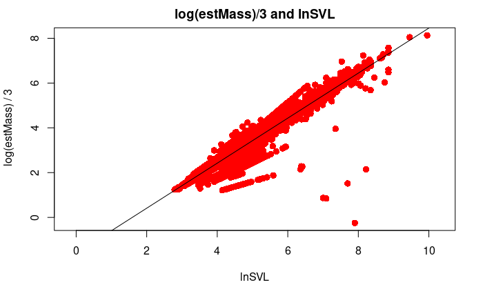

```r
g <- aggregate(cbind(lens$a, lens$b), by = list(lens$Species), mean)
colnames(g) <- c("Species", "a", "b")
shark_lens <- read.csv("../datasets/Shark.VTparity.data.csv")
shark_lens <- select(shark_lens, c(4,15,16))
colnames(shark_lens) <- c("Species",  "a","b")
lens_attempt <- merge(lens, shark_lens, by = "Species")
colnames(lens_attempt) <- c("Species","X", "a1","b1","a","b")

# changing values when they are different
ind <- which(lens_attempt$a1 != lens_attempt$a)
change <- lens_attempt[ind,]
lens_shark <- data.frame(lens$Species, lens$a, lens$b)
colnames(lens_shark) <- c("species","a","b")
#old_dat <- read.csv("../datasets/vtparity.csv")
dat <- read.csv("../datasets/vtparity.csv")
dat <- data.frame(dat)

#merging the two
#full_dat <- merge(dat, lens_shark, by = "species", all.x = T)

g <- data.frame(g)
names(g) <- c("species", "a","b")

# combo of both datasets
get <- plyr::join(g, dat, by = 'species', type = "full")

#get_mass <- mutate(get, mass_est = a * (svl^b))

#converting
get$a <- ifelse(get$a < 0, yes = exp(get$a), get$a)

transformed_dat <- saveRDS(get, file = "../output/transformed_dat.RDS")

get_mass_con <- mutate(get, lnSVL = log(svl), logMass = log(mass))

get_mass_jo <- mutate(get_mass_con, logEstMass = b * lnSVL + log((a)))

#saving
saveRDS(get_mass_jo, file = "../output/NB_massEst.RDS")
mass_est <- readRDS("../output/NB_massEst.RDS")

lm1 <- lm(mass_est$logEstMass / 3 ~  mass_est$lnSVL)
#main plot
plot(mass_est$lnSVL, mass_est$logEstMass / 3, pch = 16, cex = 1.3, col = "red",
     main = "log(estMass)/3 and lnSVL", xlab = "lnSVL", ylab = " log(estMass) / 3")
abline(lm1)
```

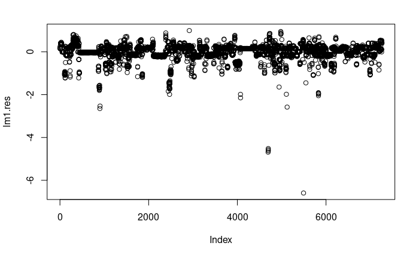

```r
# dropping based on residual
lm1.res <- (resid(lm1))
plot(lm1.res)
res_ind <- (which((lm1.res) < -2))
r <- as.data.frame(res_ind)
q <- as.numeric(rownames(r))
res_ind <- c(r$res_ind, q)
# outliers based on the residuals, not sure whether the reptiles should be dropped
res_out <- mass_est[res_ind,]

# dropped dataset
mass_est <- mass_est[-res_ind, ]
saveRDS(mass_est, file = "../output/NB_massEst_NoOutliers.RDS")

par(mfrow = c(2,1))
```

```r
hist(get_mass_jo$a)
hist(res_out$a)
```

[figure not shown]

```r
# things to be dropped based on svl and estMass
ind_out <- which(get_mass_jo$logEstMass < 0 & get_mass_jo$lnSVL > 2.5)
eye_out <- get_mass_jo[ind_out,]

par(mfrow = c(2,1))
```

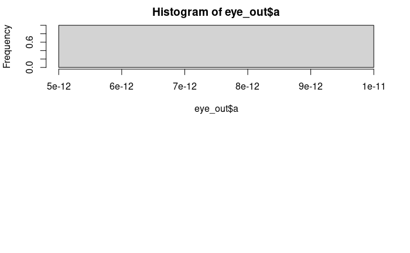

```r
hist(eye_out$a)
hist(res_out$a)
```

2. Load in matched tree and data.

```r
td0 <- readRDS("../output/chordatedata_matched_new.rds")
newmass <- readRDS("../output/NB_massEst_NoOutliers.RDS")
mergemass <- left_join(td0$dat, newmass)
mergemass <- mutate(mergemass, lnSize=ifelse(is.na(logMass)==TRUE, logEstMass/3, logMass/3))
mergemass$lnSize[mergemass$class=="Actinopterygii" & is.na(mergemass$lnSize)] <- (3.0904 * mergemass$svl[mergemass$class=="Actinopterygii" & is.na(mergemass$lnSize)]^0.007)/3
mergemass$species <- td0$phy$tip.label
td <- make.treedata(td0$phy, mergemass)
```

Can skip these. Comparison with timetree of life.

```r
# With the timetree of life
ttol <- load("~/repos/aRbor/treetimer/data/ttolData.rda")
td2 <- make.treedata(ttolData$phy, ndat)
```

```r
cat("Original dataset \n")
table(dat[['class']])
cat("My supertree \n")
table(td[['order']])
#cat("TimeTree of Life \n")
#table(td2[['order']])
```

3. Exploration with castor and juvenile/adult terrestriality. Doesn’t work great!!!

```r
rmtd <- filter(td, !is.na(repmode))
priortable <- matrix(0, nrow=length(rmtd$phy$tip.label), ncol=4)
x <-y <-0
for(i in 1:nrow(priortable)){
  if(rmtd[['repmode']][i]==1){
    if(x==0){
       priortable[i, c(3,4)] <- c(1,0)
       x <- 5
    } else {
       priortable[i, c(3,4)] <- NA
    }


  } else {
    if(y==0){
       priortable[i, c(1,2)] <- c(1,0)
       y <- 5
    } else {
    priortable[i, c(1,2)] <- NA
    }
  }
}
```

```r
rmtd <- filter(td, !is.na(repmode))#removing NAs
```

```r
rmMtd <- rmtd#filter(rmtd, !is.na(adMort), !order %in% c("Anura", "Caudata", "Gymnophiona"))
p1 <- contMap(rmMtd$phy, rmMtd[['repmode']], fsize=0.1)
p1 <- setMap(p1, c("#3498db", "#f1c40f", "#e74c3c"))
pdf("./repmode.pdf", height=20, width=20)
plot(p1, fsize=0.2, type="fan")
dev.off()
```

```r
rmASR <- castor::asr_mk_model(rmtd$phy, rmtd[['repmode']]+1, rate_model = "ARD") #ancestral state for reproductive mode
```

```r
#pdf("./repmode.pdf", height=100, width=6)
plot(rmtd$phy, type="fan", show.tip.label=FALSE, cex=0.2)
# ancestral state for ad and juv enviornment
terr2td <- filter(td, !is.na(AdTerr)) # this has 14k juv and adult, removing NA
# converting to 00 -- 11
t2 <- terr2td$dat
t2['new'] <- NA
t2$new <- as.integer(case_when(
      t2$juvTerr == 1 & t2$AdTerr == 1 ~ "1",
      t2$juvTerr == 1 & t2$AdTerr == 0 ~ "2",
      t2$juvTerr == 0 & t2$AdTerr == 1 ~ "3",
      t2$juvTerr == 0 & t2$AdTerr == 0 ~ "4"
    ))
Ad_ASR <- castor::asr_mk_model(tree = terr2td$phy, tip_states = t2$new, rate_model = "ARD")
solution <- Ad_ASR$transition_matrix
rownames(solution) <- c("11","10","01","00")
colnames(solution) <- c("11","10","01","00")
solution
```

```r
# meh
pdf("./JuvAdTerr.pdf", height=100, width=6)
plot(terr2td$phy, show.tip.label=TRUE, cex=0.2)
nodelabels(cex=0.25, pie=Ad_ASR$ancestral_likelihoods,piecol=c("blue","green","red","purple"), col="transparent", lwd=0.01)
tiplabels(cex=0.25, pch=21, bg=c("blue", "green", "red", "purple")[t2[['new']]], col=c("blue", "green", "red", "purple")[t2[['new']]])
dev.off()
```

```r
pdf("./repmode_full.pdf", height=100, width=6)
plot(rmtd$phy, show.tip.label=TRUE, cex=0.2)
nodelabels(cex=0.25, pie=rmASR$ancestral_likelihoods, piecol=c("#bdc3c7", "#e74c3c"), col="transparent", lwd=0.01)
tiplabels(cex=0.25, pch=21, bg=c("#bdc3c7", "#e74c3c")[rmtd[['repmode']]+1], col=c("#bdc3c7", "#e74c3c")[rmtd[['repmode']]+1])
#nodelabels(cex=0.25, pie=rmASR$likelihoods, piecol=c("#bdc3c7", "#34495e", "#e74c3c", "#f1c40f"), col="transparent", lwd=0.01)
#tiplabels(cex=0.25, pch=21, bg=c("#bdc3c7", "#e74c3c")[rmtd[['repmode']]+1], col=c("#bdc3c7", "#e74c3c")[rmtd[['repmode']]+1])
dev.off()
```

```r
plot(rmtd[['log.AaM']], rmtd[['juvMort']])
```

4. Phylolm analyses Get cases that have reproductive mode

```r
library(phylolm)
rmtd <- filter(td, !is.na(repmode))#removing NAs
table(rmtd$dat$order)
rmtd <- mutate(rmtd, scjMort = scale(juvMort)[,1], scadMort = scale(adMort)[,1], lnLongevity=log(longevity))
rmtd$dat$species <- rmtd$phy$tip.label
#rmtd$dat$AdTerr[is.na(rmtd$dat$AdTerr) & rmtd$dat$order=="Squamata"] <- 1
```

Load in size estimates for non-bird/mammals from a threshold model - THESE ARE TERRIBLE! Need a better link between SVL and MASS.

```r
#nonmammsize <- readRDS("./sizeEstDF.rds")
rmtd <- mutate(rmtd, lnSize = logMass3, lnLifespan = log(longevity))

splist1 <- gsub(" ", "_", nonmammsize$species)
splist2 <- gsub(" ", "_", rmtd$dat$species)
nonmammsize <- nonmammsize[-which(!splist1 %in% splist2),]
splist1 <- splist1[-which(!splist1 %in% splist2)]
index <- match(splist1, splist2)
rmtd$dat$lnSize[index] <- nonmammsize$size.thresh
rmtd$dat$lnLifespan[index] <- nonmammsize$lifespan.thresh
plot(rmtd$dat$lnLongevity, rmtd$dat$lnLifespan)
plot(rmtd$dat$lnMass3, rmtd$dat$lnSize)
```

Try again but with a regression approach

```r
#Regression approach to combining size
lmsize <- lm(I(rmtd$dat$lnMass/3) ~ rmtd$dat$lnSVL)
#nonmammsize <- readRDS("./sizeEstDF.rds")
rmtd <- mutate(rmtd, lnSize = lnMass/3, lnLifespan = log(longevity))
rmtd$dat$lnSize[is.na(rmtd$dat$lnSize)] <- rmtd$dat$lnSVL[is.na(rmtd$dat$lnSize)]*lmsize$coef[2] + lmsize$coef[1]
#splist1 <- gsub(" ", "_", nonmammsize$species)
#splist2 <- gsub(" ", "_", rmtd$dat$species)
##nonmammsize <- nonmammsize[-which(!splist1 %in% splist2),]
#splist1 <- splist1[-which(!splist1 %in% splist2)]
#index <- match(splist1, splist2)
#rmtd$dat$lnSize[index] <- nonmammsize$size.thresh
#rmtd$dat$lnLifespan[index] <- nonmammsize$lifespan.thresh
#plot(rmtd$dat$lnLongevity, rmtd$dat$lnLifespan)
plot(rmtd$dat$lnSVL, rmtd$dat$lnMass/3)
abline(lmsize)
#points(rmtd$dat$lnMass/3, rmtd$dat$lnSVL)
```

Some patches and some fits to get predictions

```r
#rmtd$dat$AdTerr[is.na(rmtd$dat$AdTerr) & rmtd$dat$order=="Squamata"] <- 1
rmMtd <- filter(rmtd, !is.na(adMort), !is.na(IF), !is.na(lnSize), !is.na(juvMort))
## Patches:
rmMtd$dat$AdTerr[rmMtd$dat$species=="Typhlonectes_compressicauda"] <- 0
```

```
Unknown or uninitialised column: `species`.
```

```r
rmMtd$dat$repmode[rmMtd$dat$species=="Uromastyx_acanthinura"] <- 0
```

```
Unknown or uninitialised column: `species`.
```

```r
rmMtd$dat$repmode[rmMtd$dat$species=="Pogona_vitticeps"] <- 0
```

```
Unknown or uninitialised column: `species`.
```

```r
table(rmMtd$dat$order)
```

```
    Acipenseriformes         Albuliformes           Amiiformes       Anguilliformes                Anura       Atheriniformes         Aulopiformes                 Aves    Batrachoidiformes
                   0                    0                    0                    1                  121                    1                    2                  823                    0
        Beloniformes         Beryciformes              Caudata       Cetomimiformes        Characiformes         Clupeiformes        Cypriniformes   Cyprinodontiformes          Elopiformes
                   3                    1                   74                    0                    4                    1                    1                    3                    0
         Esociformes           Gadiformes    Gasterosteiformes      Gobiesociformes     Gonorynchiformes          Gymnophiona        Gymnotiformes         Lampriformes         Lophiiformes
                   0                    1                    0                    0                    0                    1                    0                    0                    2
            Mammalia         Mugiliformes       Myctophiformes     Notacanthiformes        Ophidiiformes         Osmeriformes    Osteoglossiformes          Perciformes    Pleuronectiformes
                1253                    0                    0                    0                    1                    1                    0                   17                    2
     Polymixiiformes  Saccopharyngiformes        Salmoniformes      Scorpaeniformes               Sharks         Siluriformes             Squamata Stephanoberyciformes         Stomiiformes
                   0                    0                    0                    3                  115                    6                  270                    0                    0
    Synbranchiformes      Syngnathiformes    Tetraodontiformes            Zeiformes
                   0                    0                    0                    0
```

```r
sum(table(rmMtd$dat$order))
```

```
[1] 2707
```

```r
rownames(rmMtd$dat) <- rmMtd$phy$tip.label
```

```
Setting row names on a tibble is deprecated.
```

```r
#glmfit <- phyloglm(repmode ~ scjMort*AdTerr + scadMort*AdTerr, data=rmMtd$dat, phy=rmMtd$phy, btol=20)
#glmfitstep <- phyloglmstep(repmode ~ scjMort*AdTerr*scadMort*IF, data=rmMtd$dat, phy=rmMtd$phy, btol=20)
#oglmfit <- glm(repmode ~ 1 + scjMort + scadMort + juvTerr + scjMort:juvTerr + scadMort:juvTerr, data=rmMtd$dat)
glmfitalt2 <- glm(repmode ~ scadMort*AdTerr + IF + lnLongevity + scjMort*Terr, data=rmMtd$dat)
```

```
Error in eval(predvars, data, env) : object 'scadMort' not found
```

```r
#summary(glmfitstep)
summary(glmfitalt1)
summary(glmfitalt2)
summary(glmfitalt3)
summary(glmfitalt4)
summary(glmfitalt5)
```

Choose one of the models and get predictions in the dataframe rmMtd that we can compare and plot

```r
model <- glmfitalt3
rmMtd$dat$predicted  <- round(model$fitted.values,4)
rmMtd$dat$residual  <- round(model$residuals,4)
par(mar=c(10,5,1,1))
boxplot(predicted ~ repmode + class, data=rmMtd$dat, las=2, xlab="", col=c("#f1c40f", "#e74c3c"))
plot(rmMtd$dat$predicted, jitter(rmMtd$dat$repmode))
```

V. DOESN’T RUN - CAUSES CRASH. Trying to use phylopars.

```r
#rmTtd <- filter(rmtd, !is.na(AdTerr), order=="Sharks")
rmtd$phy$edge.length[rmtd$phy$edge.length==0] <- 0.01
rmtd$phy <- phytools::force.ultrametric(rmtd$phy)
rmTtd <- filter(rmtd, order=="Sharks")
pparsalt1 <- Rphylopars::phylopars.lm(repmode ~ scadMort, trait_data=rmtd$dat, tree=rmTtd$phy)
summary(pparsalt1)
```

6. Making contmaps for clade subsets

```r
sharktd <-filter(rmMtd, class %in% c("Sharks"))
p1 <- phytools::contMap(sharktd$phy, sharktd[['repmode']], fsize=0.5)
p2 <- phytools::contMap(sharktd$phy, sharktd[['predicted']], fsize=0.5)
p3 <- phytools::contMap(sharktd$phy, abs(sharktd[['residual']]), fsize=0.5)
p1 <- setMap(p1, c("#3498db", "#f1c40f", "#e74c3c"))
p2 <- setMap(p2, c("#3498db", "#f1c40f", "#e74c3c"))
p3 <- setMap(p3, c("#3498db", "#f1c40f", "#e74c3c"))
#pdf("./sharkpredict.pdf", width=20, height=15)
par(mfrow=c(1,3))
plot(p1, ftype="off")
plot(p2, ftype="off")
plot(p3, ftype="off")
#dev.off()
```

```r
amphibtd <-filter(rmMtd, class %in% c("Amphibia","Reptilia"))
p1 <- phytools::contMap(amphibtd$phy, amphibtd[['repmode']], fsize=0.5, )
p2 <- phytools::contMap(amphibtd$phy, amphibtd[['predicted']], fsize=0.5)
p3 <- phytools::contMap(amphibtd$phy, amphibtd[['residual']], fsize=0.5)
p1 <- setMap(p1, c("#3498db", "#f1c40f", "#e74c3c"))
p2 <- setMap(p2, c("#3498db", "#f1c40f", "#e74c3c"))
p3 <- setMap(p3, c("#3498db", "#f1c40f", "#e74c3c"))
#pdf("./amphibpredict.pdf", width=20, height=15)
par(mfrow=c(1,3))
plot(p1)
plot(p2)
plot(p3)
#dev.off()
```

```r
fishclass <- unique(rmMtd$dat$class[!rmMtd$dat$class %in% c("Sharks", "Mammalia", "Reptilia", "Aves", "Amphibia")])
```

7. Making RGL 3d plots. Needs to have the predicted values from section IV.

```r
library(scatterplot3d)
library(rgl)
library(car)
#View(arrange(amphibtd$dat, desc(predicted)))
predscale <- floor((rmMtd$dat$predicted-min(rmMtd$dat$predicted))/diff(range(rmMtd$dat$predicted))*99)+1
#scatter3d(x=rmMtd$dat$lnSize, y=rmMtd$dat$scadMort, z=rmMtd$dat$scjMort,  xlab="Size", ylab="Juv. Mortality", zlab="Adult Mortality",pch=21,point.col=colorRampPalette(c("#3498db", "#2ecc71", "#f1c40f", "#e74c3c"))(100)[predscale], surface=FALSE, sphere.size=predscale^(1/3))
.rmMtd <- rmMtd
predscale <- floor((.rmMtd$dat$predicted-min(rmMtd$dat$predicted))/diff(range(rmMtd$dat$predicted))*99)+1
spherecol <- colorRampPalette(c("#3498db", "#e74c3c"))(2)[.rmMtd$dat$repmode+1]
terrcol <-  colorRampPalette(c("#2980b9", "#e67e22"))(2)[.rmMtd$dat$Terr+1]
pmsDat <- cbind(BS=.rmMtd$dat$logMass3, AM=.rmMtd$dat$scadMort, OM=.rmMtd$dat$scjMort)
rownames(pmsDat) <- .rmMtd$phy$tip.label

scatter3d(x=.rmMtd$dat$scadMort, y=.rmMtd$dat$scjMort, z=.rmMtd$dat$lnSize,  xlab="Adult Mortality", ylab="Juv. Mortality", zlab="Size", point.alpha=10, fogtype="none",point.col=terrcol, surface=FALSE, sphere.size=(predscale/3)^(1/3))
#Identify3d(x=.rmMtd$dat$scadMort, y=.rmMtd$dat$scjMort, z=.rmMtd$dat$lnSize,labels=.rmMtd$dat$species, offset=0.05)
```

Mammals

```r
.rmMtd <- mutate(rmMtd, plotcode = 1 + 2*(class %in% c("Mammalia")) + repmode )
predscale <- floor((.rmMtd$dat$predicted-min(rmMtd$dat$predicted))/diff(range(rmMtd$dat$predicted))*99)+1
spherecol <- c("#ecf0f1", "#bdc3c7", "#3498db", "#e74c3c")[.rmMtd$dat$plotcode]
#pmsDat <- cbind(BS=.rmMtd$dat$lnSize, AM=.rmMtd$dat$scadMort, OM=.rmMtd$dat$scjMort)
#rownames(pmsDat) <- .rmMtd$phy$tip.label


scatter3d(x=.rmMtd$dat$scadMort, y=.rmMtd$dat$scjMort, z=.rmMtd$dat$logMass3,  xlab="Adult Mortality", ylab="Juv. Mortality", zlab="Size", point.alpha=10, fogtype="none",point.col=spherecol, surface=FALSE, sphere.size=(predscale/3)^(1/3))
#Identify3d(x=.rmMtd$dat$scadMort, y=.rmMtd$dat$scjMort, z=.rmMtd$dat$lnSize,labels=.rmMtd$dat$species, offset=0.05)
```

Birds

```r
.rmMtd <- mutate(rmMtd, plotcode = 1 + 2*(class %in% c("Aves")) + repmode )
predscale <- floor((.rmMtd$dat$predicted-min(rmMtd$dat$predicted))/diff(range(rmMtd$dat$predicted))*99)+1
spherecol <- c("#ecf0f1", "#bdc3c7", "#3498db", "#e74c3c")[.rmMtd$dat$plotcode]
#pmsDat <- cbind(BS=.rmMtd$dat$lnSize, AM=.rmMtd$dat$scadMort, OM=.rmMtd$dat$scjMort)
#rownames(pmsDat) <- .rmMtd$phy$tip.label


scatter3d(x=.rmMtd$dat$scadMort, y=.rmMtd$dat$scjMort, z=.rmMtd$dat$lnSize,  xlab="Adult Mortality", ylab="Juv. Mortality", zlab="Size", point.alpha=10, fogtype="none",point.col=spherecol, surface=FALSE, sphere.size=(predscale/3)^(1/3))
#Identify3d(x=.rmMtd$dat$scadMort, y=.rmMtd$dat$scjMort, z=.rmMtd$dat$lnSize,labels=.rmMtd$dat$species, offset=0.05)
```

Amphibians

```r
.rmMtd <- mutate(rmMtd, plotcode = 1 + 2*(class %in% c("Amphibia", "Reptilia", "Actinopterygii")) + repmode )
predscale <- floor((.rmMtd$dat$predicted-min(rmMtd$dat$predicted))/diff(range(rmMtd$dat$predicted))*99)+1
spherecol <- c("#ecf0f1", "#bdc3c7", "#3498db", "#e74c3c")[.rmMtd$dat$plotcode]
#pmsDat <- cbind(BS=.rmMtd$dat$lnSize, AM=.rmMtd$dat$scadMort, OM=.rmMtd$dat$scjMort)
#rownames(pmsDat) <- .rmMtd$phy$tip.label

scatter3d(x=.rmMtd$dat$scadMort, y=.rmMtd$dat$scjMort, z=.rmMtd$dat$lnSize,  xlab="Adult Mortality", ylab="Juv. Mortality", zlab="Size", point.alpha=10, fogtype="none",point.col=spherecol, surface=FALSE, sphere.size=(predscale/3)^(1/3))
#Identify3d(x=.rmMtd$dat$scadMort, y=.rmMtd$dat$scjMort, z=.rmMtd$dat$lnSize,labels=.rmMtd$dat$species, offset=0.05)
```

Squamates

```r
.rmMtd <- mutate(rmMtd, plotcode = 1 + 2*(class %in% c("Reptilia")) + repmode )
predscale <- floor((.rmMtd$dat$predicted-min(rmMtd$dat$predicted))/diff(range(rmMtd$dat$predicted))*99)+1
spherecol <- c("#ecf0f1", "#bdc3c7", "#3498db", "#e74c3c")[.rmMtd$dat$plotcode]
#pmsDat <- cbind(BS=.rmMtd$dat$lnSize, AM=.rmMtd$dat$scadMort, OM=.rmMtd$dat$scjMort)
#rownames(pmsDat) <- .rmMtd$phy$tip.label


scatter3d(x=.rmMtd$dat$scadMort, y=.rmMtd$dat$scjMort, z=.rmMtd$dat$lnSize,  xlab="Adult Mortality", ylab="Juv. Mortality", zlab="Size", point.alpha=10, fogtype="none",point.col=spherecol, surface=FALSE, sphere.size=(predscale/3)^(1/3))
#Identify3d(x=.rmMtd$dat$scadMort, y=.rmMtd$dat$scjMort, z=.rmMtd$dat$lnSize,labels=.rmMtd$dat$species, offset=0.05)
```

Sharks

```r
.rmMtd <- mutate(rmMtd, plotcode = 1 + 2*(class %in% c("Sharks", "Mammalia", "Aves")) + repmode )
predscale <- floor((.rmMtd$dat$predicted-min(rmMtd$dat$predicted))/diff(range(rmMtd$dat$predicted))*99)+1
spherecol <- c("#ecf0f1", "#bdc3c7", "#3498db", "#e74c3c")[.rmMtd$dat$plotcode]
#pmsDat <- cbind(BS=.rmMtd$dat$lnSize, AM=.rmMtd$dat$scadMort, OM=.rmMtd$dat$scjMort)
#rownames(pmsDat) <- .rmMtd$phy$tip.label


scatter3d(x=.rmMtd$dat$scadMort, y=.rmMtd$dat$scjMort, z=.rmMtd$dat$lnSize,  xlab="Adult Mortality", ylab="Juv. Mortality", zlab="Size", point.alpha=10, fogtype="none",point.col=spherecol, surface=FALSE, sphere.size=(predscale/3)^(1/3))
#Identify3d(x=.rmMtd$dat$scadMort, y=.rmMtd$dat$scjMort, z=.rmMtd$dat$lnSize,labels=.rmMtd$dat$species, offset=0.05)
```

Bony Fish

```r
.rmMtd <- mutate(rmMtd, plotcode = 1 + 2*(!class %in% c("Sharks", "Aves", "Amphibia", "Reptilia", "Mammalia")) + repmode )
predscale <- floor((.rmMtd$dat$predicted-min(rmMtd$dat$predicted))/diff(range(rmMtd$dat$predicted))*99)+1
spherecol <- c("#ecf0f1", "#bdc3c7", "#3498db", "#e74c3c")[.rmMtd$dat$plotcode]
#pmsDat <- cbind(BS=.rmMtd$dat$lnSize, AM=.rmMtd$dat$scadMort, OM=.rmMtd$dat$scjMort)
#rownames(pmsDat) <- .rmMtd$phy$tip.label


scatter3d(x=.rmMtd$dat$scadMort, y=.rmMtd$dat$scjMort, z=.rmMtd$dat$lnSize,  xlab="Adult Mortality", ylab="Juv. Mortality", zlab="Size", point.alpha=10, fogtype="none",point.col=spherecol, surface=FALSE, sphere.size=(predscale/3)^(1/3))
#Identify3d(x=.rmMtd$dat$scadMort, y=.rmMtd$dat$scjMort, z=.rmMtd$dat$lnSize,labels=.rmMtd$dat$species, offset=0.05)
```

```r
.rmMtd <- filter(rmMtd, class %in% c("Amphibia", "Reptilia", ) | family %in% c("Balaenopteridae", "Soricidae", "Cricetidae"))
predscale <- floor((.rmMtd$dat$predicted-min(rmMtd$dat$predicted))/diff(range(rmMtd$dat$predicted))*99)+1
spherecol <- colorRampPalette(c("#3498db", "#e74c3c"))(2)[.rmMtd$dat$repmode+1]
pmsDat <- cbind(BS=.rmMtd$dat$lnSize, AM=.rmMtd$dat$scadMort, OM=.rmMtd$dat$scjMort)
rownames(pmsDat) <- .rmMtd$phy$tip.label
#phylomorphospace3d(.rmMtd$phy, X=pmsDat, control=list(spin=FALSE, ftype="off", method="dynamic",point.col=spherecol, sphere.size=(predscale)^1/3))


scatter3d(x=.rmMtd$dat$scadMort, y=.rmMtd$dat$scjMort, z=.rmMtd$dat$lnSize,  xlab="Adult Mortality", ylab="Juv. Mortality", zlab="Size", point.alpha=10, fogtype="none",point.col=spherecol, surface=FALSE, sphere.size=(predscale/3)^(1/3))
#Identify3d(x=.rmMtd$dat$scadMort, y=.rmMtd$dat$scjMort, z=.rmMtd$dat$lnSize,labels=.rmMtd$dat$species, offset=0.05)

#scatterplot3d(x=rmMtd$dat$lnSize, y=rmMtd$dat$scadMort, z=rmMtd$dat$scjMort, xlab="Size", ylab="Juv. Mortality", zlab="Adult Mortality",pch=21, bg=colorRampPalette(c("#3498db", "#2ecc71", "#f1c40f", "#e74c3c"))(100)[predscale])
```

```r
.rmMtd <- filter(rmMtd, !class %in% c("Amphibia", "Reptilia", "Aves", "Mammalia") | family %in% c("Balaenopteridae", "Soricidae", "Cricetidae") | species %in% c("Mantella laevigata"))
predscale <- floor((.rmMtd$dat$predicted-min(rmMtd$dat$predicted))/diff(range(rmMtd$dat$predicted))*99)+1
spherecol <- colorRampPalette(c("#3498db", "#e74c3c"))(2)[.rmMtd$dat$repmode+1]
pmsDat <- cbind(BS=.rmMtd$dat$lnSize, AM=.rmMtd$dat$scadMort, OM=.rmMtd$dat$scjMort)
rownames(pmsDat) <- .rmMtd$phy$tip.label
#phylomorphospace3d(.rmMtd$phy, X=pmsDat, control=list(spin=FALSE, ftype="off", method="dynamic",point.col=spherecol, sphere.size=(predscale)^1/3))


scatter3d(x=.rmMtd$dat$scadMort, y=.rmMtd$dat$scjMort, z=.rmMtd$dat$lnSize,  xlab="Adult Mortality", ylab="Juv. Mortality", zlab="Size", point.alpha=10, fogtype="none",point.col=spherecol, surface=FALSE, sphere.size=(predscale/3)^(1/3))
#Identify3d(x=.rmMtd$dat$scadMort, y=.rmMtd$dat$scjMort, z=.rmMtd$dat$lnSize,labels=.rmMtd$dat$species, offset=0.05)
```

#Ternary plots

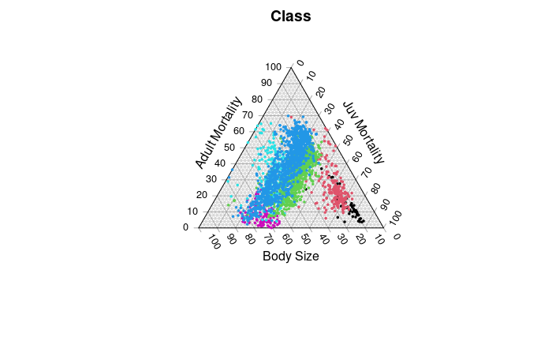

```r
library(Ternary)
terntd <- td %>% filter(!is.na(juvMort), !is.na(adMort), !is.na(lnSize), !is.na(repmode)) %>% mutate(scSize = scale(lnSize), scadMort=scale(adMort), scjMort=scale(juvMort)) %>% mutate(scSize=scSize-min(scSize, na.rm=TRUE), scadMort=scadMort-min(scadMort, na.rm=TRUE), scjMort=scjMort-min(scjMort, na.rm=TRUE)) %>% mutate(trAdMort = scadMort/(scadMort+scjMort+scSize), trJMort = scjMort/(scadMort+scjMort+scSize), trSize = scSize/(scadMort+scjMort+scSize))
terntd$dat$species <- terntd$phy$tip.label
terntd <-filter(terntd, !is.na(trJMort), !is.na(trAdMort), !is.na(trSize)) %>% select(order, class, family,species, trAdMort, trJMort, trSize, repmode, AdTerr, Terr)
Ternary::TernaryPlot(alab="Adult Mortality", blab="Juv Mortality", clab="Body Size", main="Class")
TernaryPoints(terntd$dat[,5:7], pch=21, cex=0.35, bg=terntd$dat$class, col=terntd$dat$class)
```

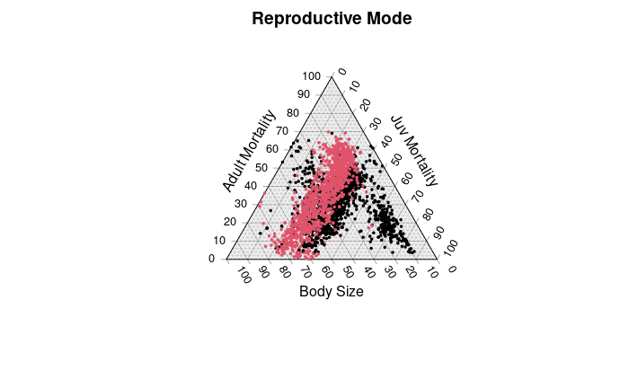

```r
Ternary::TernaryPlot(alab="Adult Mortality", blab="Juv Mortality", clab="Body Size", main="Reproductive Mode")
TernaryPoints(terntd$dat[,5:7], pch=21, cex=0.35, bg=terntd$dat$repmode+1, col=terntd$dat$repmode+1)
```

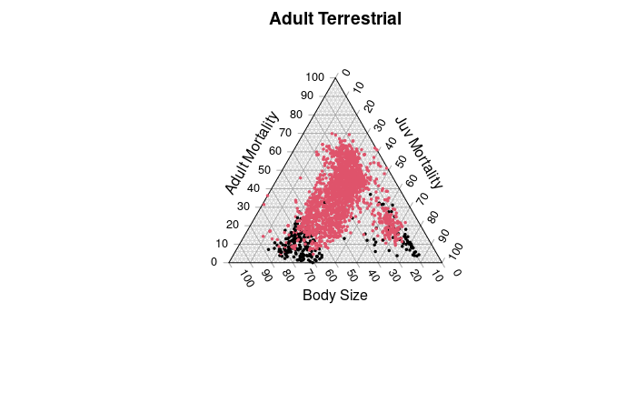

```r
Ternary::TernaryPlot(alab="Adult Mortality", blab="Juv Mortality", clab="Body Size", main="Adult Terrestrial")
TernaryPoints(terntd$dat[,5:7], pch=21, cex=0.35, bg=terntd$dat$AdTerr+1, col=terntd$dat$AdTerr+1)
```

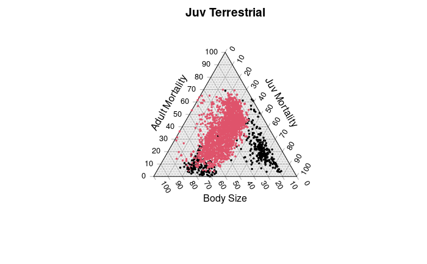

```r
Ternary::TernaryPlot(alab="Adult Mortality", blab="Juv Mortality", clab="Body Size", main="Juv Terrestrial")
TernaryPoints(terntd$dat[,5:7], pch=21, cex=0.35, bg=terntd$dat$Terr+1, col=terntd$dat$Terr+1)
```

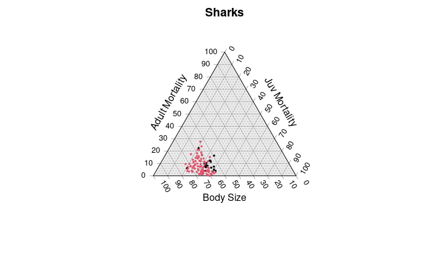

```r
Ternary::TernaryPlot(alab="Adult Mortality", blab="Juv Mortality", clab="Body Size", main="Sharks")
.terntd <- filter(terntd, order=="Sharks")
TernaryPoints(.terntd$dat[,5:7], pch=21, cex=0.35, bg=.terntd$dat$repmode+1, col=.terntd$dat$repmode+1)
```

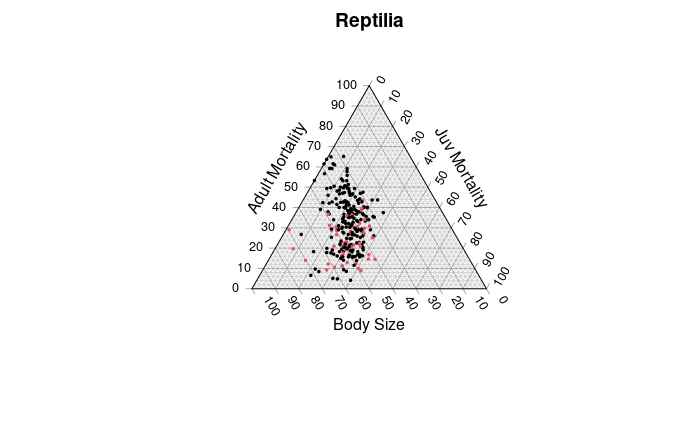

```r
Ternary::TernaryPlot(alab="Adult Mortality", blab="Juv Mortality", clab="Body Size", main="Reptilia")
.terntd <- filter(terntd, class=="Reptilia")
TernaryPoints(.terntd$dat[,5:7], pch=21, cex=0.35, bg=.terntd$dat$repmode+1, col=.terntd$dat$repmode+1)
```

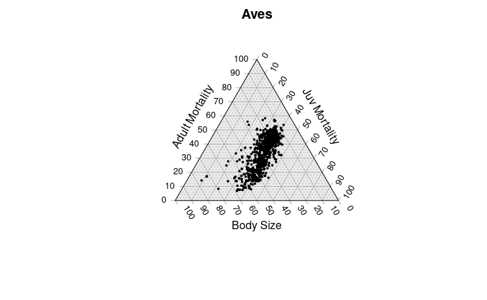

```r
Ternary::TernaryPlot(alab="Adult Mortality", blab="Juv Mortality", clab="Body Size", main="Aves")
.terntd <- filter(terntd, class=="Aves")
TernaryPoints(.terntd$dat[,5:7], pch=21, cex=0.35, bg=.terntd$dat$repmode+1, col=.terntd$dat$repmode+1)
```

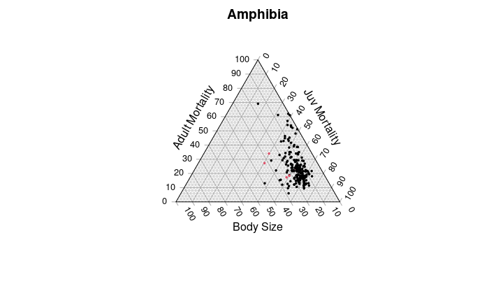

```r
Ternary::TernaryPlot(alab="Adult Mortality", blab="Juv Mortality", clab="Body Size", main="Amphibia")
.terntd <- filter(terntd, class=="Amphibia")
TernaryPoints(.terntd$dat[,5:7], pch=21, cex=0.35, bg=.terntd$dat$repmode+1, col=.terntd$dat$repmode+1)
```

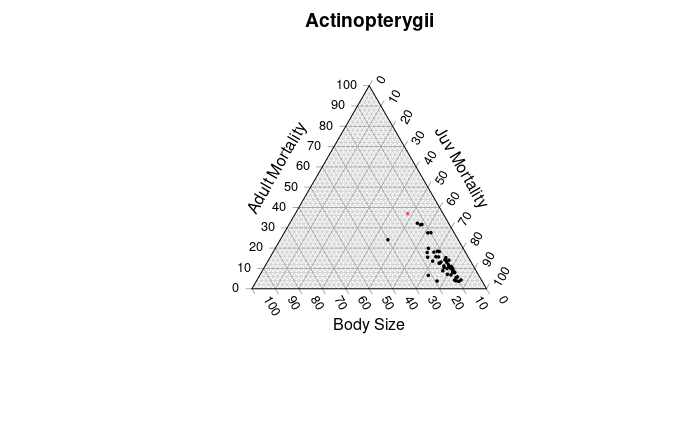

```r
Ternary::TernaryPlot(alab="Adult Mortality", blab="Juv Mortality", clab="Body Size", main="Actinopterygii")
.terntd <- filter(terntd, class=="Actinopterygii")
TernaryPoints(.terntd$dat[,5:7], pch=21, cex=0.35, bg=.terntd$dat$repmode+1, col=.terntd$dat$repmode+1)
```

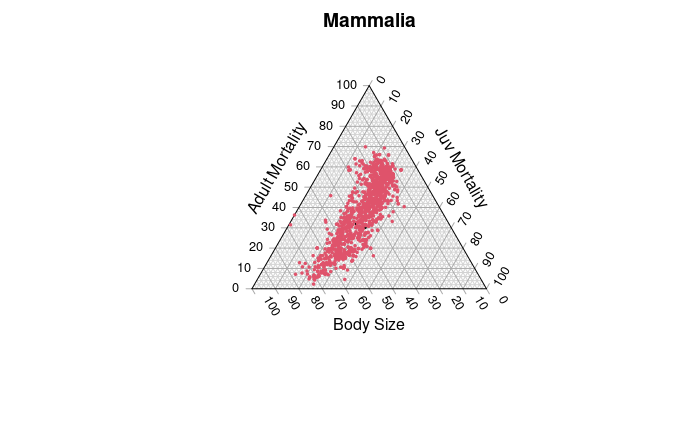

```r
Ternary::TernaryPlot(alab="Adult Mortality", blab="Juv Mortality", clab="Body Size", main="Mammalia")
.terntd <- filter(terntd, class=="Mammalia")
TernaryPoints(.terntd$dat[,5:7], pch=21, cex=0.35, bg=.terntd$dat$repmode+1, col=.terntd$dat$repmode+1)
```

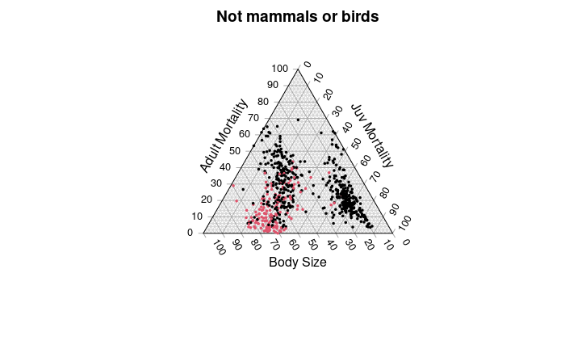

```r
Ternary::TernaryPlot(alab="Adult Mortality", blab="Juv Mortality", clab="Body Size", main="Not mammals or birds")
.terntd <- filter(terntd, !class %in% c("Mammalia", "Aves"))
TernaryPoints(.terntd$dat[,5:7], pch=21, cex=0.35, bg=.terntd$dat$repmode+1, col=.terntd$dat$repmode+1)
```

```r
#plot(terntd$dat$trAdMort, terntd$dat$trJMort)
```

## Now fit to discrete ternary plot data

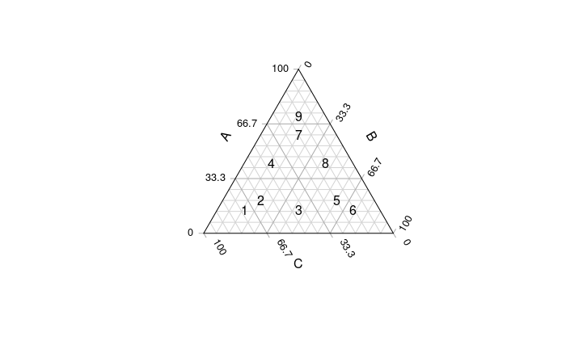

```r
library(Ternary)
library(MCMCpack)
library(combinat)
library(dplyr)

dat <- dplyr::select(terntd$dat, 5,6,7)

bins <- 3

combos <- combinat::combn(rep(1:bins,3), 3) ## Create all combinations of values 1:bins
sums <- apply(combos, 2, sum) #Sum the 3 values for the 3 traits
combos <- combos[,sums %in% c(bins+2, bins+1)] #Only retain those that sum to bins+2 and bins+1 (fit in the triangle)
cells <- t(combos[,!duplicated(apply(combos, 2,paste, collapse=""))]) #remove duplicated bin combinations
colnames(cells) <- c("A", "B", "C") #label traits
cells <- cells[order(cells[,3],(bins+1)-cells[,1],(bins+1)-cells[,2], decreasing=TRUE),] #reorder the cells to be prettier
cellnames <- apply(cells, 1, paste, collapse="") #Give the cells a state label
ddat <- apply(dat, 2, cut,breaks=seq(0,1, length.out=bins+1), labels=1:bins) #Find where the data falls in the state space
ddat <- match(apply(ddat, 1, paste, collapse=""), cellnames) #match the data's state to the state label
terntd <- mutate(terntd, ddat=ddat)


Ternary::TernaryPlot(alab="A", blab="B", clab="C", grid.lines = 3) #Plot with points labeled by their numeric state value (values with more than two digits won't show up right)
ssq <- seq(0, 1, length.out=bins+4)[c(2,4,6)]
midcells <- cbind(ssq[cells[,1]], ssq[cells[,2]], ssq[cells[,3]])
for(i in 1:nrow(midcells)){
  midcells[i,] <- midcells[i,]/sum(midcells[i,])
}
colnames(midcells) <- colnames(cells)
TernaryPoints(midcells, pch=as.character(1:9))
```

```r
#TernaryPoints(dat, pch=as.character(ddat))

Q <- as.matrix(dist(cells))
Q[Q!=1] <- 0
Q
```

```
  1 2 3 4 5 6 7 8 9
1 0 1 0 0 0 0 0 0 0
2 1 0 1 1 0 0 0 0 0
3 0 1 0 0 1 0 0 0 0
4 0 1 0 0 0 0 1 0 0
5 0 0 1 0 0 1 0 1 0
6 0 0 0 0 1 0 0 0 0
7 0 0 0 1 0 0 0 1 1
8 0 0 0 0 1 0 1 0 0
9 0 0 0 0 0 0 1 0 0
```

```r
library(castor)
.terntd <- filter(terntd, !is.na(ddat))
ERfit <- castor::fit_mk(.terntd$phy, 9, tip_states=.terntd[['ddat']], rate_model=Q)
ERfit
```

```
$success
[1] TRUE

$Nstates
[1] 9

$transition_matrix
              [,1]         [,2]         [,3]         [,4]         [,5]         [,6]         [,7]         [,8]         [,9]
 [1,] -0.007846054  0.007846054  0.000000000  0.000000000  0.000000000  0.000000000  0.000000000  0.000000000  0.000000000
 [2,]  0.007846054 -0.023538161  0.007846054  0.007846054  0.000000000  0.000000000  0.000000000  0.000000000  0.000000000
 [3,]  0.000000000  0.007846054 -0.015692107  0.000000000  0.007846054  0.000000000  0.000000000  0.000000000  0.000000000
 [4,]  0.000000000  0.007846054  0.000000000 -0.015692107  0.000000000  0.000000000  0.007846054  0.000000000  0.000000000
 [5,]  0.000000000  0.000000000  0.007846054  0.000000000 -0.023538161  0.007846054  0.000000000  0.007846054  0.000000000
 [6,]  0.000000000  0.000000000  0.000000000  0.000000000  0.007846054 -0.007846054  0.000000000  0.000000000  0.000000000
 [7,]  0.000000000  0.000000000  0.000000000  0.007846054  0.000000000  0.000000000 -0.023538161  0.007846054  0.007846054
 [8,]  0.000000000  0.000000000  0.000000000  0.000000000  0.007846054  0.000000000  0.007846054 -0.015692107  0.000000000
 [9,]  0.000000000  0.000000000  0.000000000  0.000000000  0.000000000  0.000000000  0.007846054  0.000000000 -0.007846054

$loglikelihood
[1] -2594.014

$Niterations
[1] 9

$Nevaluations
function
      21

$converged
[1] TRUE

$guess_rate
[1] 0.08150559

$standard_errors
NULL

$CI50lower
NULL

$CI50upper
NULL

$CI95lower
NULL

$CI95upper
NULL
```

```r
## Viviparity
.terntd <- mutate(.terntd, ddatpm = ddat+repmode*9) %>% filter(!class %in% c("Mammalia", "Aves"))
DM1 <- DM2 <- diag(9)
diag(DM1) <- 2
diag(DM2) <- 3

Qpm0.ER <- rbind(cbind(Q, DM1), cbind(DM1, Q))
Qpm0.Asym <- rbind(cbind(Q, DM1), cbind(DM2, Q))
rownames(Qpm0.ER) <- colnames(Qpm0.ER) <- 1:18
rownames(Qpm0.Asym) <- colnames(Qpm0.Asym) <- 1:18
Fit.pm0.ER <- castor::fit_mk(.terntd$phy, 18, tip_states=.terntd[['ddatpm']], rate_model=Qpm0.ER)
Fit.pm0.Asym <- castor::fit_mk(.terntd$phy, 18, tip_states=.terntd[['ddatpm']], rate_model=Qpm0.Asym)
Fit.pm0.ER
```

```
$success
[1] TRUE

$Nstates
[1] 18

$transition_matrix
               [,1]          [,2]          [,3]          [,4]          [,5]          [,6]          [,7]          [,8]          [,9]
 [1,] -0.0052154328  0.0043670589  0.0000000000  0.0000000000  0.0000000000  0.0000000000  0.0000000000  0.0000000000  0.0000000000
 [2,]  0.0043670589 -0.0139495506  0.0043670589  0.0043670589  0.0000000000  0.0000000000  0.0000000000  0.0000000000  0.0000000000
 [3,]  0.0000000000  0.0043670589 -0.0095824917  0.0000000000  0.0043670589  0.0000000000  0.0000000000  0.0000000000  0.0000000000
 [4,]  0.0000000000  0.0043670589  0.0000000000 -0.0095824917  0.0000000000  0.0000000000  0.0043670589  0.0000000000  0.0000000000
 [5,]  0.0000000000  0.0000000000  0.0043670589  0.0000000000 -0.0139495506  0.0043670589  0.0000000000  0.0043670589  0.0000000000
 [6,]  0.0000000000  0.0000000000  0.0000000000  0.0000000000  0.0043670589 -0.0052154328  0.0000000000  0.0000000000  0.0000000000
 [7,]  0.0000000000  0.0000000000  0.0000000000  0.0043670589  0.0000000000  0.0000000000 -0.0139495506  0.0043670589  0.0043670589
 [8,]  0.0000000000  0.0000000000  0.0000000000  0.0000000000  0.0043670589  0.0000000000  0.0043670589 -0.0095824917  0.0000000000
 [9,]  0.0000000000  0.0000000000  0.0000000000  0.0000000000  0.0000000000  0.0000000000  0.0043670589  0.0000000000 -0.0052154328
[10,]  0.0008483739  0.0000000000  0.0000000000  0.0000000000  0.0000000000  0.0000000000  0.0000000000  0.0000000000  0.0000000000
[11,]  0.0000000000  0.0008483739  0.0000000000  0.0000000000  0.0000000000  0.0000000000  0.0000000000  0.0000000000  0.0000000000
[12,]  0.0000000000  0.0000000000  0.0008483739  0.0000000000  0.0000000000  0.0000000000  0.0000000000  0.0000000000  0.0000000000
[13,]  0.0000000000  0.0000000000  0.0000000000  0.0008483739  0.0000000000  0.0000000000  0.0000000000  0.0000000000  0.0000000000
[14,]  0.0000000000  0.0000000000  0.0000000000  0.0000000000  0.0008483739  0.0000000000  0.0000000000  0.0000000000  0.0000000000
[15,]  0.0000000000  0.0000000000  0.0000000000  0.0000000000  0.0000000000  0.0008483739  0.0000000000  0.0000000000  0.0000000000
[16,]  0.0000000000  0.0000000000  0.0000000000  0.0000000000  0.0000000000  0.0000000000  0.0008483739  0.0000000000  0.0000000000
[17,]  0.0000000000  0.0000000000  0.0000000000  0.0000000000  0.0000000000  0.0000000000  0.0000000000  0.0008483739  0.0000000000
[18,]  0.0000000000  0.0000000000  0.0000000000  0.0000000000  0.0000000000  0.0000000000  0.0000000000  0.0000000000  0.0008483739
              [,10]         [,11]         [,12]         [,13]         [,14]         [,15]         [,16]         [,17]         [,18]
 [1,]  0.0008483739  0.0000000000  0.0000000000  0.0000000000  0.0000000000  0.0000000000  0.0000000000  0.0000000000  0.0000000000
 [2,]  0.0000000000  0.0008483739  0.0000000000  0.0000000000  0.0000000000  0.0000000000  0.0000000000  0.0000000000  0.0000000000
 [3,]  0.0000000000  0.0000000000  0.0008483739  0.0000000000  0.0000000000  0.0000000000  0.0000000000  0.0000000000  0.0000000000
 [4,]  0.0000000000  0.0000000000  0.0000000000  0.0008483739  0.0000000000  0.0000000000  0.0000000000  0.0000000000  0.0000000000
 [5,]  0.0000000000  0.0000000000  0.0000000000  0.0000000000  0.0008483739  0.0000000000  0.0000000000  0.0000000000  0.0000000000
 [6,]  0.0000000000  0.0000000000  0.0000000000  0.0000000000  0.0000000000  0.0008483739  0.0000000000  0.0000000000  0.0000000000
 [7,]  0.0000000000  0.0000000000  0.0000000000  0.0000000000  0.0000000000  0.0000000000  0.0008483739  0.0000000000  0.0000000000
 [8,]  0.0000000000  0.0000000000  0.0000000000  0.0000000000  0.0000000000  0.0000000000  0.0000000000  0.0008483739  0.0000000000
 [9,]  0.0000000000  0.0000000000  0.0000000000  0.0000000000  0.0000000000  0.0000000000  0.0000000000  0.0000000000  0.0008483739
[10,] -0.0052154328  0.0043670589  0.0000000000  0.0000000000  0.0000000000  0.0000000000  0.0000000000  0.0000000000  0.0000000000
[11,]  0.0043670589 -0.0139495506  0.0043670589  0.0043670589  0.0000000000  0.0000000000  0.0000000000  0.0000000000  0.0000000000
[12,]  0.0000000000  0.0043670589 -0.0095824917  0.0000000000  0.0043670589  0.0000000000  0.0000000000  0.0000000000  0.0000000000
[13,]  0.0000000000  0.0043670589  0.0000000000 -0.0095824917  0.0000000000  0.0000000000  0.0043670589  0.0000000000  0.0000000000
```

[output cut: 21 more lines]

```

$standard_errors
NULL

$CI50lower
NULL

$CI50upper
NULL

$CI95lower
NULL

$CI95upper
NULL
```

```r
Fit.pm0.Asym
```

```
$success
[1] TRUE

$Nstates
[1] 18

$transition_matrix
               [,1]          [,2]          [,3]          [,4]          [,5]          [,6]          [,7]          [,8]          [,9]
 [1,] -0.0052395763  0.0043670505  0.0000000000  0.0000000000  0.0000000000  0.0000000000  0.0000000000  0.0000000000  0.0000000000
 [2,]  0.0043670505 -0.0139736774  0.0043670505  0.0043670505  0.0000000000  0.0000000000  0.0000000000  0.0000000000  0.0000000000
 [3,]  0.0000000000  0.0043670505 -0.0096066269  0.0000000000  0.0043670505  0.0000000000  0.0000000000  0.0000000000  0.0000000000
 [4,]  0.0000000000  0.0043670505  0.0000000000 -0.0096066269  0.0000000000  0.0000000000  0.0043670505  0.0000000000  0.0000000000
 [5,]  0.0000000000  0.0000000000  0.0043670505  0.0000000000 -0.0139736774  0.0043670505  0.0000000000  0.0043670505  0.0000000000
 [6,]  0.0000000000  0.0000000000  0.0000000000  0.0000000000  0.0043670505 -0.0052395763  0.0000000000  0.0000000000  0.0000000000
 [7,]  0.0000000000  0.0000000000  0.0000000000  0.0043670505  0.0000000000  0.0000000000 -0.0139736774  0.0043670505  0.0043670505
 [8,]  0.0000000000  0.0000000000  0.0000000000  0.0000000000  0.0043670505  0.0000000000  0.0043670505 -0.0096066269  0.0000000000
 [9,]  0.0000000000  0.0000000000  0.0000000000  0.0000000000  0.0000000000  0.0000000000  0.0043670505  0.0000000000 -0.0052395763
[10,]  0.0007479923  0.0000000000  0.0000000000  0.0000000000  0.0000000000  0.0000000000  0.0000000000  0.0000000000  0.0000000000
[11,]  0.0000000000  0.0007479923  0.0000000000  0.0000000000  0.0000000000  0.0000000000  0.0000000000  0.0000000000  0.0000000000
[12,]  0.0000000000  0.0000000000  0.0007479923  0.0000000000  0.0000000000  0.0000000000  0.0000000000  0.0000000000  0.0000000000
[13,]  0.0000000000  0.0000000000  0.0000000000  0.0007479923  0.0000000000  0.0000000000  0.0000000000  0.0000000000  0.0000000000
[14,]  0.0000000000  0.0000000000  0.0000000000  0.0000000000  0.0007479923  0.0000000000  0.0000000000  0.0000000000  0.0000000000
[15,]  0.0000000000  0.0000000000  0.0000000000  0.0000000000  0.0000000000  0.0007479923  0.0000000000  0.0000000000  0.0000000000
[16,]  0.0000000000  0.0000000000  0.0000000000  0.0000000000  0.0000000000  0.0000000000  0.0007479923  0.0000000000  0.0000000000
[17,]  0.0000000000  0.0000000000  0.0000000000  0.0000000000  0.0000000000  0.0000000000  0.0000000000  0.0007479923  0.0000000000
[18,]  0.0000000000  0.0000000000  0.0000000000  0.0000000000  0.0000000000  0.0000000000  0.0000000000  0.0000000000  0.0007479923
              [,10]         [,11]         [,12]         [,13]         [,14]         [,15]         [,16]         [,17]         [,18]
 [1,]  0.0008725258  0.0000000000  0.0000000000  0.0000000000  0.0000000000  0.0000000000  0.0000000000  0.0000000000  0.0000000000
 [2,]  0.0000000000  0.0008725258  0.0000000000  0.0000000000  0.0000000000  0.0000000000  0.0000000000  0.0000000000  0.0000000000
 [3,]  0.0000000000  0.0000000000  0.0008725258  0.0000000000  0.0000000000  0.0000000000  0.0000000000  0.0000000000  0.0000000000
 [4,]  0.0000000000  0.0000000000  0.0000000000  0.0008725258  0.0000000000  0.0000000000  0.0000000000  0.0000000000  0.0000000000
 [5,]  0.0000000000  0.0000000000  0.0000000000  0.0000000000  0.0008725258  0.0000000000  0.0000000000  0.0000000000  0.0000000000
 [6,]  0.0000000000  0.0000000000  0.0000000000  0.0000000000  0.0000000000  0.0008725258  0.0000000000  0.0000000000  0.0000000000
 [7,]  0.0000000000  0.0000000000  0.0000000000  0.0000000000  0.0000000000  0.0000000000  0.0008725258  0.0000000000  0.0000000000
 [8,]  0.0000000000  0.0000000000  0.0000000000  0.0000000000  0.0000000000  0.0000000000  0.0000000000  0.0008725258  0.0000000000
 [9,]  0.0000000000  0.0000000000  0.0000000000  0.0000000000  0.0000000000  0.0000000000  0.0000000000  0.0000000000  0.0008725258
[10,] -0.0051150429  0.0043670505  0.0000000000  0.0000000000  0.0000000000  0.0000000000  0.0000000000  0.0000000000  0.0000000000
[11,]  0.0043670505 -0.0138491439  0.0043670505  0.0043670505  0.0000000000  0.0000000000  0.0000000000  0.0000000000  0.0000000000
[12,]  0.0000000000  0.0043670505 -0.0094820934  0.0000000000  0.0043670505  0.0000000000  0.0000000000  0.0000000000  0.0000000000
[13,]  0.0000000000  0.0043670505  0.0000000000 -0.0094820934  0.0000000000  0.0000000000  0.0043670505  0.0000000000  0.0000000000
```

[output cut: 21 more lines]

```

$standard_errors
NULL

$CI50lower
NULL

$CI50upper
NULL

$CI95lower
NULL

$CI95upper
NULL
```

```r
Fit.pm1235.ER$loglikelihood
```

```
[1] -897.9494
```

```r
Fit.pm1235.Asym$loglikelihood
```

```
[1] -889.3761
```

```r
.terntd <- filter(terntd, !is.na(ddat))
.terntd <- mutate(.terntd, ddatpm = ddat+repmode*9) %>% filter(!class %in% c("Mammalia", "Aves"))

DM3 <- DM4 <- diag(9)
diag(DM3) <- 1+1:9
DM3[9,9] <- 0
diag(DM4) <- 0
Qpm.ARD <- rbind(cbind(Q, DM3), cbind(DM4,Q))
colnames(Qpm.ARD) <- rownames(Qpm.ARD) <- 1:18
Fit.pm.ARD <- castor::fit_mk(.terntd$phy, 18, tip_states=.terntd[['ddatpm']], rate_model=Qpm.ARD)
```

```r
cat("\nAIC ER no parity equal across regions\n")
```

```
AIC ER no parity equal across regions
```

```r
2* max(Qpm0.ER) - 2*Fit.pm0.ER$loglikelihood
```

```
[1] 1802.865
```

```r
cat("\nAIC Asym no parity equal across regions\n")
```

```
AIC Asym no parity equal across regions
```

```r
2* max(Qpm0.Asym) - 2*Fit.pm0.Asym$loglikelihood
```

```
[1] 1804.764
```

```r
cat("\nAIC ER viviparous increased in 1235\n")
```

```
AIC ER viviparous increased in 1235
```

```r
2* max(Qpm1235.ER) - 2*Fit.pm1235.ER$loglikelihood
```

```
[1] 1801.899
```

```r
cat("\nAIC Asym viviparous increased in 1235\n")
```

```
AIC Asym viviparous increased in 1235
```

```r
2* max(Qpm1235.Asym) - 2*Fit.pm1235.Asym$loglikelihood
```

```
[1] 1788.752
```

```r
cat("\nAIC Asym viviparous ARD\n")
```

```
AIC Asym viviparous ARD
```

```r
2*max(Qpm.ARD) - 2*Fit.pm.ARD$loglikelihood
```

```
[1] 5443.9
```

```r
gains <- diag(Fit.pm.ARD$transition_matrix[1:9,10:18])
losses <- diag(Fit.pm.ARD$transition_matrix[10:18,1:9])
plot(c(1,9), c(0,0.01), type="n")
lines(1:9, gains, col="blue")
```

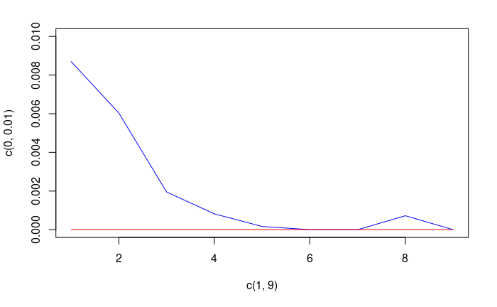

```r
lines(1:9, losses, col="red")
```

```r
relrate <- log(gains-losses+0.0001)
relratescaled <- floor((relrate - min(relrate))/(max(relrate) - min(relrate)) * 99+1)

Point2Area <- function(a, b, c){
  .ddat <- apply(cbind(a,b,c), 2, cut, breaks=seq(0,1, length.out=bins+1), labels=1:bins) #Find where the data falls in the state space
  match(paste(.ddat, collapse=""), cellnames)
}
Point2Area(1/3+0.01, 1/3-0.01, 1/3)
```

```
[1] 7
```

```r
values <- rdirichlet(10000, c(1,1,1))
region <- NULL
for(i in 1:nrow(values)){
  region[i] <- Point2Area(values[i,1], values[i, 2], values[i,3])
}

hc <- viridis::viridis(100, 0.2)
ratecol <- setNames(hc[relratescaled], 1:9)


Ternary::TernaryPlot(alab="Adult Mortality", blab="Juv Mortality", clab="Body Size", main="Not mammals or birds", grid.lines = 3)
.plotterntd <- filter(terntd, !class %in% c("Mammalia", "Aves"))
TernaryPoints(values, col=ratecol[region], bg=ratecol[region], pch=24)
```

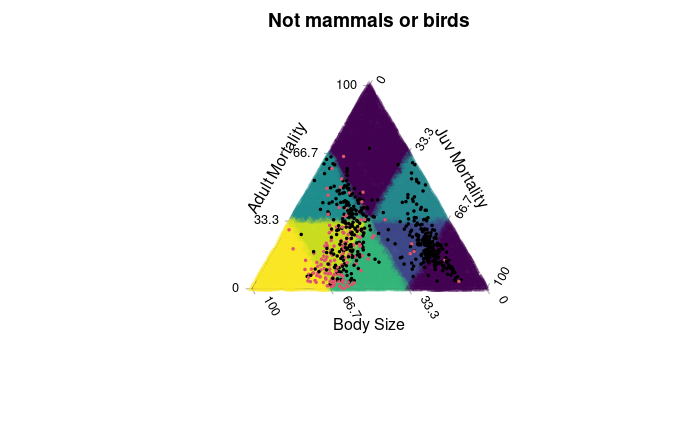

```r
TernaryPoints(.plotterntd$dat[,5:7], pch=21, cex=0.35, bg=.terntd$dat$repmode+1, col=.terntd$dat$repmode+1)
```

#VIII. New hyp. framework:

```r
library(phylolm)
rmtd <- filter(td, !is.na(repmode))#removing NAs
table(rmtd$dat$order)
rmtd <- mutate(rmtd, scjMort = scale(juvMort)[,1], scadMort = scale(adMort)[,1], lnLongevity=log(longevity), lnMass=log(mass), lnSVL =log(svl), lnSize=logMass3)
rmtd$dat$AdTerr[is.na(rmtd$dat$AdTerr) & rmtd$dat$order=="Squamata"] <- 1
```

```r
rmtd$dat$AdTerr[is.na(rmtd$dat$AdTerr) & rmtd$dat$order=="Squamata"] <- 1
rmMtd <- filter(rmtd, !is.na(adMort), !is.na(IF), !is.na(lnSize), !is.na(juvMort))
## Patches:
rmMtd$dat$AdTerr[rmMtd$dat$species=="Typhlonectes compressicauda"] <- 0
rmMtd$dat$repmode[rmMtd$dat$species=="Uromastyx acanthinura"] <- 0
rmMtd$dat$repmode[rmMtd$dat$species=="Pogona vitticeps"] <- 0


table(rmMtd$dat$order)
sum(table(rmMtd$dat$order))
rownames(rmMtd$dat) <- rmMtd$phy$tip.label
#glmfit <- phyloglm(repmode ~ scjMort*AdTerr + scadMort*AdTerr, data=rmMtd$dat, phy=rmMtd$phy, btol=20)
#glmfitstep <- phyloglmstep(repmode ~ scjMort*AdTerr*scadMort*IF, data=rmMtd$dat, phy=rmMtd$phy, btol=20)
#oglmfit <- glm(repmode ~ 1 + scjMort + scadMort + juvTerr + scjMort:juvTerr + scadMort:juvTerr, data=rmMtd$dat)
fitsjMort <- list()
fitsjMort[[1]] <- phylolm(scjMort ~ lnSize*Terr+ repmode+Terr, data=rmMtd$dat, phy=rmMtd$phy, model="lambda")
fitsjMort[[2]] <- phylolm(scjMort ~ lnSize+ lnLongevity+ repmode + Terr, data=rmMtd$dat, phy=rmMtd$phy, model="lambda")
fitsjMort[[3]] <- phylolm(scjMort ~ scadMort, data=rmMtd$dat, phy=rmMtd$phy, model="lambda")
fitsjMort[[4]] <- phylolm(scjMort ~ IF, data=rmMtd$dat, phy=rmMtd$phy, model="lambda")
fitsjMort[[5]] <- phylolm(scjMort ~ Terr, data=rmMtd$dat, phy=rmMtd$phy, model="lambda")
fitsjMort[[6]] <- phylolm(scjMort ~ lnSize, data=rmMtd$dat, phy=rmMtd$phy, model="lambda")
fitsjMort[[7]] <- phylolm(scjMort ~ lnSize*scadMort, data=rmMtd$dat, phy=rmMtd$phy, model="lambda")
```

```r
lapply(fitsjMort, summary)
```

```r
rmtd$dat$AdTerr[is.na(rmtd$dat$AdTerr) & rmtd$dat$order=="Squamata"] <- 1
rmMtd <- filter(rmtd, !is.na(adMort), !is.na(IF), !is.na(lnSize), !is.na(juvMort))
## Patches:
rmMtd$dat$AdTerr[rmMtd$dat$species=="Typhlonectes compressicauda"] <- 0
rmMtd$dat$repmode[rmMtd$dat$species=="Uromastyx acanthinura"] <- 0
rmMtd$dat$repmode[rmMtd$dat$species=="Pogona vitticeps"] <- 0


table(rmMtd$dat$order)
sum(table(rmMtd$dat$order))
rownames(rmMtd$dat) <- rmMtd$phy$tip.label
#glmfit <- phyloglm(repmode ~ scjMort*AdTerr + scadMort*AdTerr, data=rmMtd$dat, phy=rmMtd$phy, btol=20)
#glmfitstep <- phyloglmstep(repmode ~ scjMort*AdTerr*scadMort*IF, data=rmMtd$dat, phy=rmMtd$phy, btol=20)
#oglmfit <- glm(repmode ~ 1 + scjMort + scadMort + juvTerr + scjMort:juvTerr + scadMort:juvTerr, data=rmMtd$dat)
fitsadMort <- list()
fitsadMort[[1]] <- phylolm(scadMort ~ lnSize*Terr+ repmode+Terr, data=rmMtd$dat, phy=rmMtd$phy, model="lambda")
fitsadMort[[2]] <- phylolm(scadMort ~ lnSize+ lnLongevity+ repmode + Terr, data=rmMtd$dat, phy=rmMtd$phy, model="lambda")
fitsadMort[[3]] <- phylolm(scadMort ~ scjMort, data=rmMtd$dat, phy=rmMtd$phy, model="lambda")
fitsadMort[[4]] <- phylolm(scadMort ~ IF, data=rmMtd$dat, phy=rmMtd$phy, model="lambda")
fitsadMort[[5]] <- phylolm(scadMort ~ Terr, data=rmMtd$dat, phy=rmMtd$phy, model="lambda")
fitsadMort[[6]] <- phylolm(scadMort ~ lnSize, data=rmMtd$dat, phy=rmMtd$phy, model="lambda")
fitsadMort[[7]] <- phylolm(scadMort ~ lnSize*scjMort, data=rmMtd$dat, phy=rmMtd$phy, model="lambda")
```

```r
lapply(fitsadMort, summary)
```